# CORH 203 Data Visualization

Mathew Vis-Dunbar

October, 2024

> Data! data! data! […] I can’t make bricks without clay.

― Sherlock Holmes, The Adventure of the Copper Beeches

http://tinyurl.com/corh-203-slides

## [Data Literacies](https://www.statcan.gc.ca/en/wtc/data-literacy/compentencies)

The knowledge and skills you need to effectively work with data.

## Data Types

Categorical & Numeric  
Qualitative & Quantitative

## Data Visualization

The **abstraction** of data, using shapes, colour, and position.

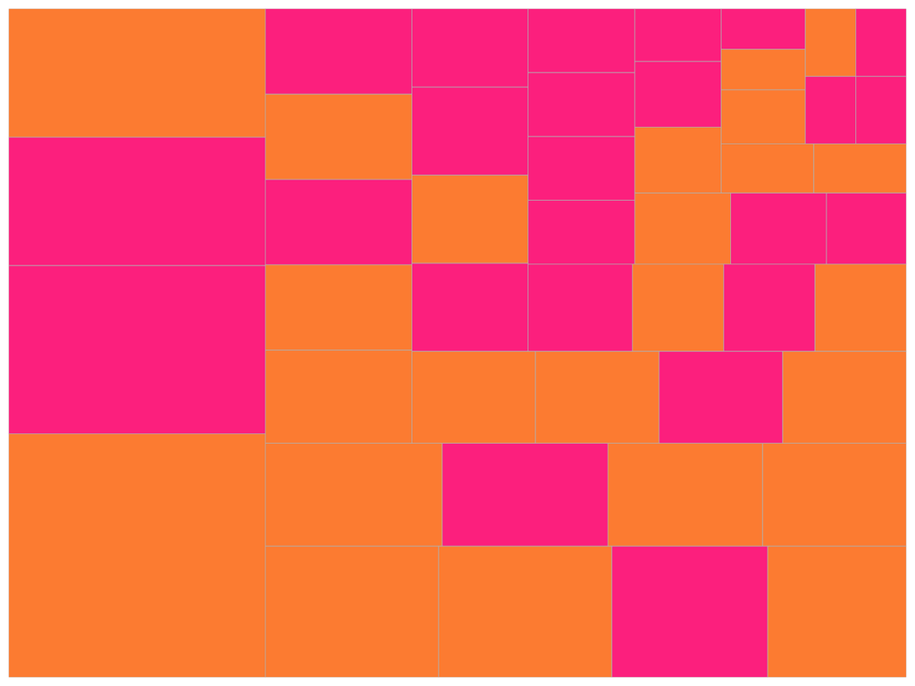

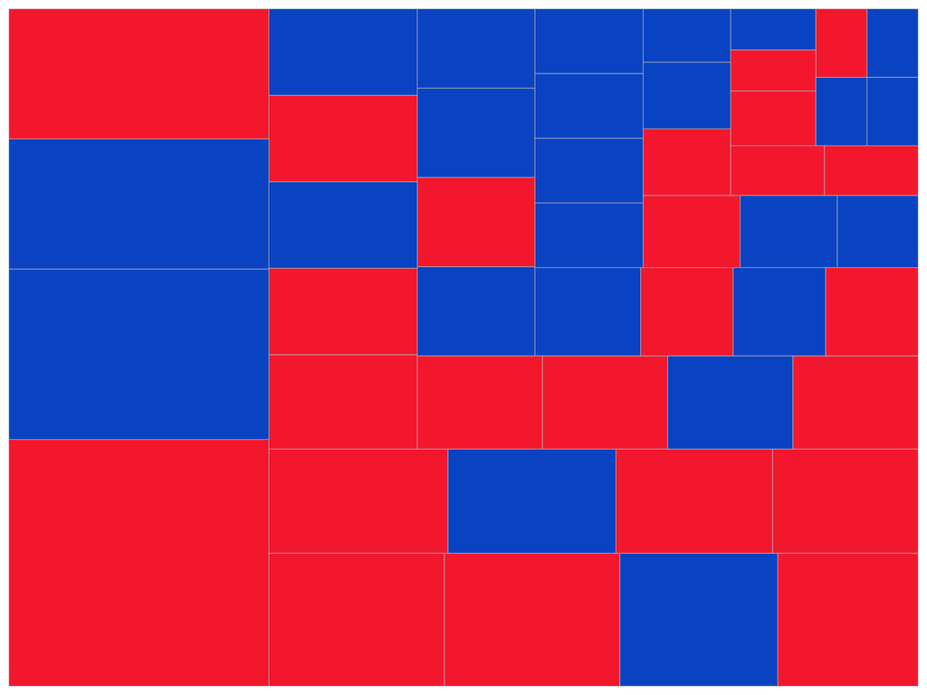

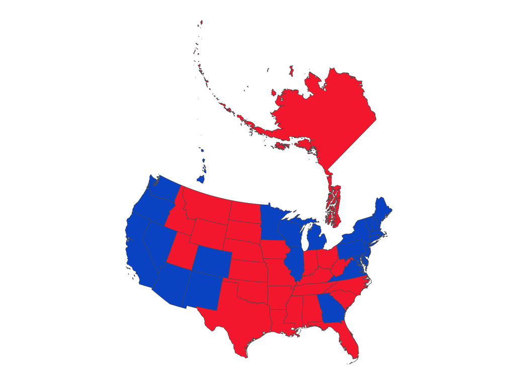

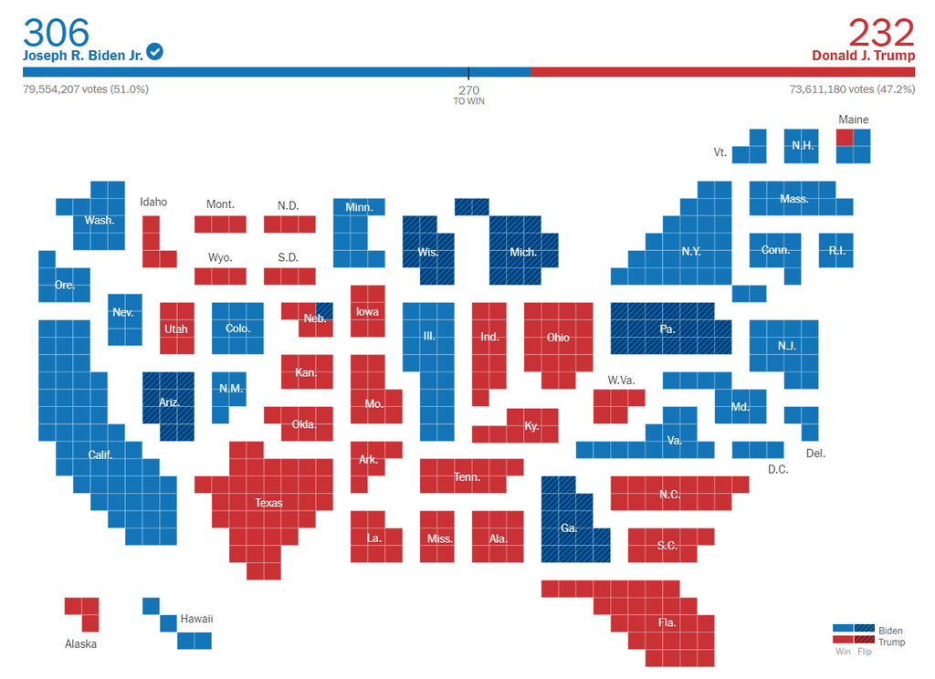

Source: https://static01.nyt.com/images/2020/11/20/learning/2020electoralvotesmapLN/2020electoralvotesmapLN-superJumbo.png?quality=75&auto=webp

> Data visualization is the graphical display of abstract information for two purposes: sense-making (also called data analysis) and communication.

Stephen Few. [Data Visualization for Human Perception](https://www.interaction-design.org/literature/book/the-encyclopedia-of-human-computer-interaction-2nd-ed).

## Sense Making

> The greatest value of a picture is when it forces us to notice what we never expected to see.

John W. Tukey (1977). “Exploratory Data Analysis”

[interactive chart not shown]

## Communication

> [T]he […] optic nerves are sending what we now know are 20 megabits a second of information back to the brain […] [It] is being transformed into information, into thinking, right as that step from the retina to the brain. And the brain is really busy, and it likes to economize. And so it’s quick to be active and jump to conclusions. So if you’re told what to look for, you can’t see anything else.

Edward Tufte. *Edward Tufte Wants You to See Better*. January 18, 2013. Talk of the Nation. https://www.npr.org/2013/01/18/169708761/edward-tufte-wants-you-to-see-better

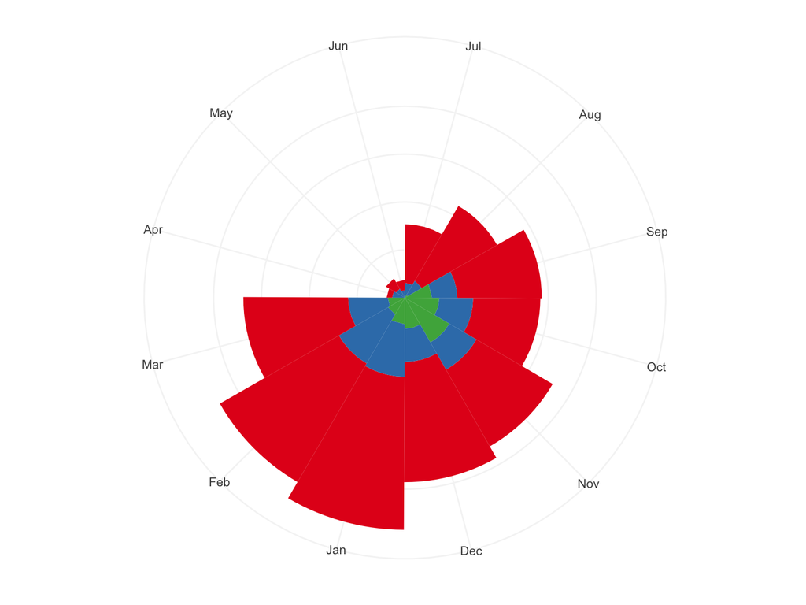

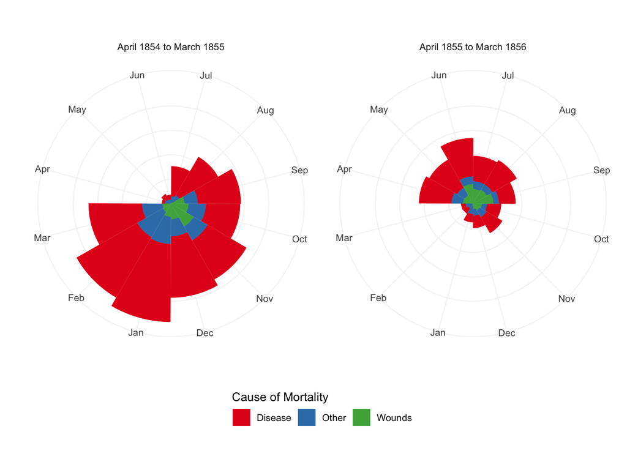

> There is no such thing as information overload, just bad design. If something is cluttered and/or confusing, fix your design.

- Edward Tufte. Attributed quote.

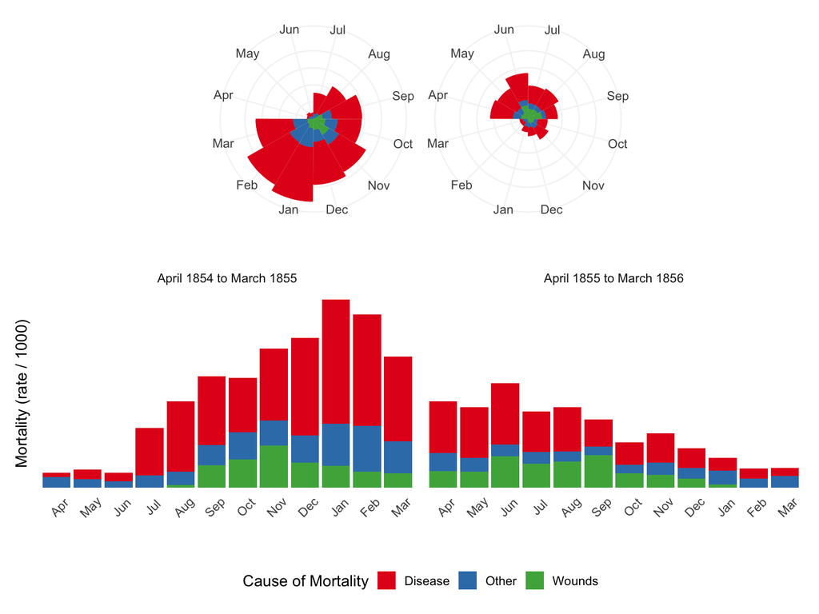

> A beautiful visualization has a clear goal, a message, or a particular perspective on the information that it is designed to convey. Access to this information should be as straightforward as possible, without sacrificing any necessary, relevant complexity.

Noah Iliinsky (2010). [On Beauty. In *Beautiful visualization: looking at data through the eyes of experts*](https://go.exlibris.link/KJLP9Jc9).